# MSD Homework 2, Problem 3

Nava Nizard (Hunter College)

2026-06-14 17:31:12.413434

# Description

This is a template for exercise 6 in Chapter 2 of [Bit By Bit: Social Research in the Digital Age](https://www.bitbybitbook.com/en/1st-ed/observing-behavior/observing-activities/) by Matt Salganik. The problem is reprinted here with some additional comments and structure to facilitate a solution.

The original problem statement:

> In a widely discussed paper, Michel and colleagues ([2011](https://doi.org/10.1126/science.1199644)) analyzed the content of more than five million digitized books in an attempt to identify long-term cultural trends. The data that they used has now been released as the Google NGrams dataset, and so we can use the data to replicate and extend some of their work.

> In one of the many results in the paper, Michel and colleagues argued that we are forgetting faster and faster. For a particular year, say “1883,” they calculated the proportion of 1-grams published in each year between 1875 and 1975 that were “1883”. They reasoned that this proportion is a measure of the interest in events that happened in that year. In their figure 3a, they plotted the usage trajectories for three years: 1883, 1910, and 1950. These three years share a common pattern: little use before that year, then a spike, then decay. Next, to quantify the rate of decay for each year, Michel and colleagues calculated the “half-life” of each year for all years between 1875 and 1975. In their figure 3a (inset), they showed that the half-life of each year is decreasing, and they argued that this means that we are forgetting the past faster and faster. They used Version 1 of the English language corpus, but subsequently Google has released a second version of the corpus. Please read all the parts of the question before you begin coding.

> This activity will give you practice writing reusable code, interpreting results, and data wrangling (such as working with awkward files and handling missing data). This activity will also help you get up and running with a rich and interesting dataset.

The full paper can be found [here](https://aidenlab.org/papers/Science.Culturomics.pdf), and this is the original figure 3a that you’re going to replicate:

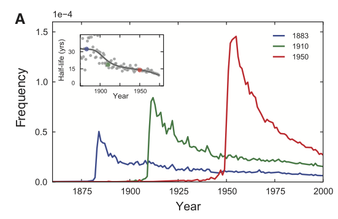

# Part A

> Get the raw data from the [Google Books NGram Viewer website](http://storage.googleapis.com/books/ngrams/books/datasetsv2.html). In particular, you should use version 2 of the English language corpus, which was released on July 1, 2012. Uncompressed, this file is 1.4GB.

## Step 1: Get and clean the raw data

Edit the `01_download_1grams.sh` file to download the `googlebooks-eng-all-1gram-20120701-1.gz` file and the `02_filter_1grams.sh` file to filter the original 1gram file to only lines where the ngram matches a year (output to a file named `year_counts.tsv`). Then edit the `03_download_totals.sh` file to down the `googlebooks-eng-all-totalcounts-20120701.txt` and file and the `04_reformat_totals.sh` file to reformat the total counts file to a valid csv (output to a file named `total_counts.csv`).

## Step 2: Load the cleaned data

```r
here() # Show the detected project root
```

```
## [1] "/mnt/c/Users/nava/Documents/coursework"
```

```r
# Build a path to a the year_counts.tsv and total_counts.csv files in the "ngrams" folder
year_counts_data_path <- here("week3/ngrams", "year_counts.tsv")
total_counts_data_path <- here("week3/ngrams", "total_counts.csv")

year_counts <- read_tsv(year_counts_data_path,
                         col_names = c('term', 'year', 'volume', 'book_count'))
total_counts <- read_csv(total_counts_data_path,
                          col_names = c('year', 'total_volume', 'page_count', 'book_count'))
```

## Step 3: Check dimensions

There are 53393 lines in the `year_counts` data frame, and 425 lines in the `total_counts` data frame.

# Part B

> Recreate the main part of figure 3a of Michel et al. (2011). To recreate this figure, you will need two files: the one you downloaded in part (a) and the “total counts” file, which you can use to convert the raw counts into proportions. Note that the total counts file has a structure that may make it a bit hard to read in. Does version 2 of the NGram data produce similar results to those presented in Michel et al. (2011), which are based on version 1 data?

## Step 1: Join ngram year counts and totals

Join the raw year term counts with the total counts and divide to get a proportion of mentions for each term normalized by the total counts for each year.

```r
years_and_totals <- left_join(year_counts, total_counts, by = 'year') %>%
  select(-book_count.x, -book_count.y) %>%
  mutate(proportion_of_mentions = volume / total_volume)
```

## Step 2: Plot the main figure 3a

Plot the proportion of mentions for the terms “1883”, “1910”, and “1950” over time from 1850 to 2012, as in the main figure 3a of the original paper. Use the `percent` function from the `scales` package for a readable y axis. Each term should have a different color, it’s nice if these match the original paper but not strictly necessary.

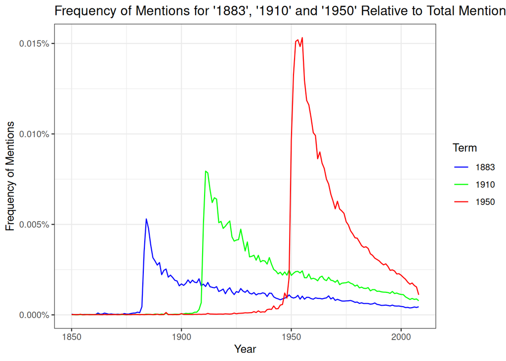

```r
years_and_totals %>%
  filter(term == '1883' | term == '1910' | term == '1950') %>%
  filter(year >= 1850 & year <= 2012) %>%
  mutate(term = as.character(term)) %>% # Since 'term' is numeric, need to typecast it in order to use scale_manual, since scale_manual expects a discrete variable (not continuous)
  ggplot(aes(x = year, y = proportion_of_mentions, color = term)) +
  geom_line() +
  labs(x = 'Year',
       y = 'Frequency of Mentions',
       title = 'Frequency of Mentions for \'1883\', \'1910\' and \'1950\' Relative to Total Mentions',
       color = 'Term') +
  scale_y_continuous(labels = percent_format()) +
  scale_color_manual(values = c('1883' = "blue", '1910' = "green", '1950' = "red"))
```

## Step 3: Conclusion

Does version 2 of the NGram data produce similar results to those presented in Michel et al. (2011), which are based on version 1 data?

Yes, the version 2 data produces very similar results. The terms ‘1883’, ‘1910’, and ‘1950’ all follow the same general pattern as in the original paper. Mentions increase as the year approaches, peak around that year, and then decrease over time. While the exact values are not the same, the overall shape and trend of the curves are very similar to those shown in Michel et al. (2011).

# Part C

> Now check your graph against the graph created by the [NGram Viewer](https://books.google.com/ngrams/).

## Step 1: Compare to the NGram Viewer

Go to the ngram viewer, enter the terms “1883”, “1910”, and “1950” and take a screenshot.

## Step 2: Compare and contrast

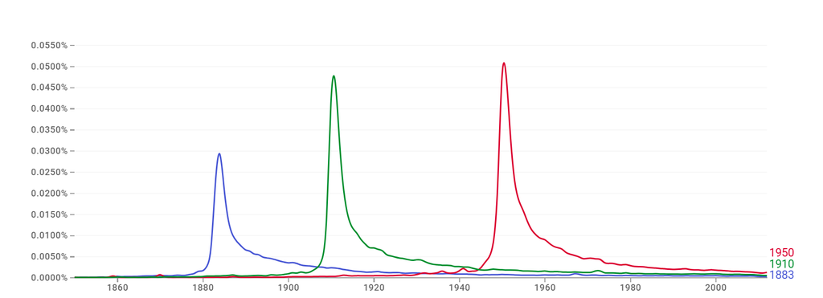

The Ngram Viewer’s plot appears smoother and shows less variation between the ‘1910’ and ‘1950’ peak frequencies compared to our dataset. In our data, the ‘1910’ frequency is 0.007%, and ‘1950’ is 0.015%, whereas in the Ngram Viewer, these values are 0.047% and 0.05% , respectively

# Part D

> Recreate figure 3a (main figure), but change the y-axis to be the raw mention count (not the rate of mentions).

## Step 1: Plot the main figure 3a with raw counts

Plot the raw counts for the terms “1883”, “1910”, and “1950” over time from 1850 to 2012. Use the `comma` function from the `scales` package for a readable y axis. The colors for each term should match your last plot, and it’s nice if these match the original paper but not strictly necessary.

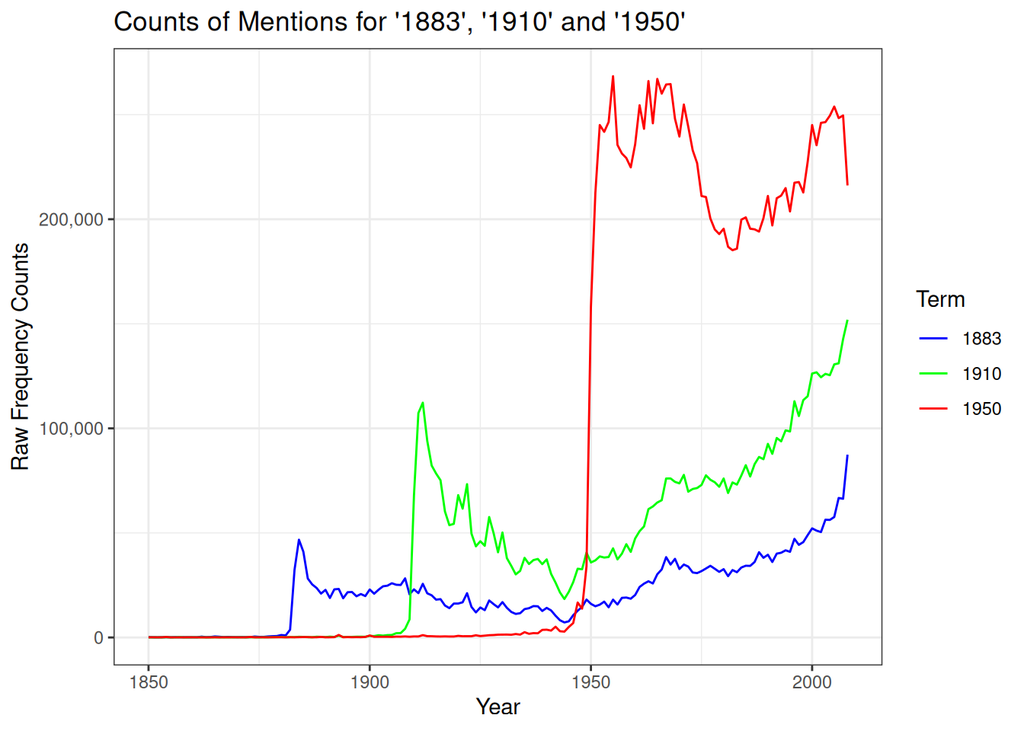

```r
years_and_totals %>%
  filter(term == '1883' | term == '1910' | term == '1950') %>%
  filter(year >= 1850 & year <= 2012) %>%
  mutate(term = as.character(term)) %>% # Since 'term' is numeric, need to typecast it in order to use scale_manual, since scale_manual expects a discrete variable (not continuous)
  ggplot(aes(x = year, y = volume, color = term)) +
  geom_line() +
  labs(x = 'Year',
       y = 'Raw Frequency Counts',
       title = 'Counts of Mentions for \'1883\', \'1910\' and \'1950\'',
       color = 'Term') +
  scale_y_continuous(labels = comma_format()) +
  scale_color_manual(values = c('1883' = "blue", '1910' = "green", '1950' = "red"))
```

# Part E

> Does the difference between (b) and (d) lead you to reevaluate any of the results of Michel et al. (2011). Why or why not?

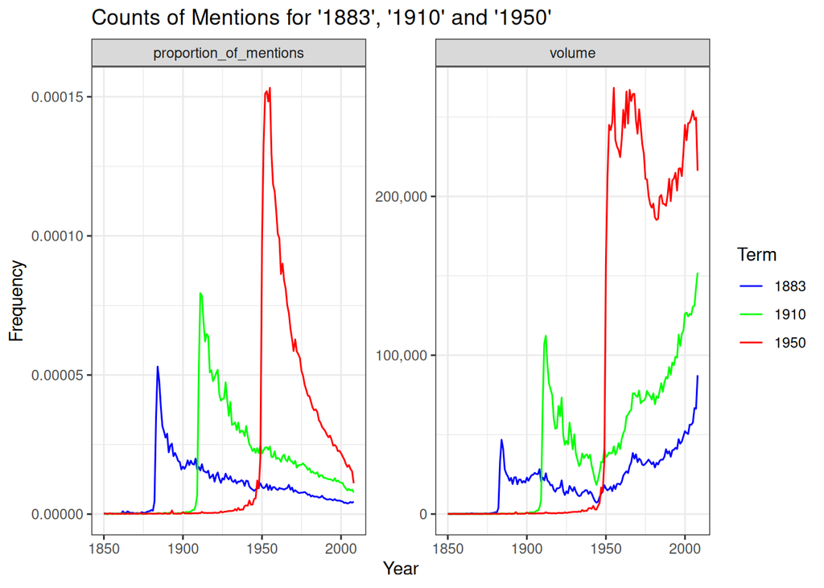

```r
years_and_totals %>%
  filter(term == '1883' | term == '1910' | term == '1950') %>%
  filter(year >= 1850 & year <= 2012) %>%
  mutate(term = as.character(term)) %>% # Since 'term' is numeric, need to typecast it in order to use scale_manual, since scale_manual expects a discrete variable (not continuous)
  pivot_longer(names_to = 'frequency_type', values_to = 'frequency', cols = c('volume', 'proportion_of_mentions')) %>%
  ggplot(aes(x = year, y = frequency, color = term)) +
  geom_line() +
  labs(x = 'Year',
       y = 'Frequency',
       title = 'Counts of Mentions for \'1883\', \'1910\' and \'1950\'',
       color = 'Term') +
  scale_y_continuous(labels = comma_format()) +
  scale_color_manual(values = c('1883' = "blue", '1910' = "green", '1950' = "red")) +
  facet_wrap(~frequency_type, scales = 'free_y')
```

## Step 1: Plot the totals

Plot the total counts for each year over time, from 1850 to 2012. Use the `comma` function from the `scales` package for a readable y axis. There should be only one line on this plot (not three).

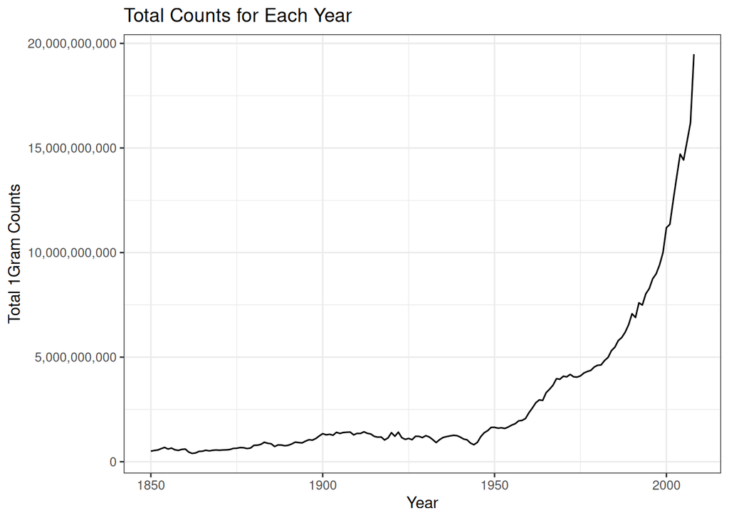

```r
years_and_totals %>%
  filter(year >= 1850 & year <= 2012) %>%
  ggplot(aes(x = year, y = total_volume)) +
  geom_line() +
  scale_y_continuous(label = comma) +
  labs(x = 'Year',
       y = 'Total 1Gram Counts',
       title = 'Total Counts for Each Year')
```

## Step 2: Conclusion

Does the difference between (b) and (d) lead you to reevaluate any of the results of Michel et al. (2011). Why or why not?

Yes. It’s possible that we’re not actually forgetting these words at a faster rate. As time went on, the total number of words increased, so the denominator used to calculate the proportions became larger. Because of this, the proportion could decrease even if the actual number of times a word appeared stayed about the same. In other words, the word made up a smaller share of the overall vocabulary simply because there were more total words. This suggests that the decrease in proportion may be due to growth in the total number of words rather than a true decline in the word’s usage.

# Part F

> Now, using the proportion of mentions, replicate the inset of figure 3a. That is, for each year between 1875 and 1975, calculate the half-life of that year. The half-life is defined to be the number of years that pass before the proportion of mentions reaches half its peak value. Note that Michel et al. (2011) do something more complicated to estimate the half-life — see section III.6 of the Supporting Online Information—but they claim that both approaches produce similar results. Does version 2 of the NGram data produce similar results to those presented in Michel et al. (2011), which are based on version 1 data? (Hint: Don’t be surprised if it doesn’t.)

## Step 1: Compute peak mentions

For each year term, find the year where its proportion of mentions peaks (hits its highest value). Store this in an intermediate dataframe.

```r
peak_year_for_each_term <- years_and_totals %>%
  group_by(term) %>%
  filter(year >= term) %>% # the peak happens around the year it refers to (aka avoid picking up noise from very small total counts in early years).
  filter(proportion_of_mentions == max(proportion_of_mentions)) %>%
  select(term, year, proportion_of_mentions) %>%
  rename(peak_year = year, peak_proportion = proportion_of_mentions)
```

## Step 2: Compute half-lifes

Now, for each year term, find the minimum number of years it takes for the proportion of mentions to decline from its peak value to half its peak value. Store this in an intermediate data frame.

```r
peak_year_for_each_term <- peak_year_for_each_term %>%
  mutate(half_life_value = peak_proportion / 2)

years_and_half_lives <- left_join(years_and_totals, peak_year_for_each_term, by = 'term')

years_and_half_lives <- years_and_half_lives %>%
  filter(proportion_of_mentions <= half_life_value) %>%
  group_by(term) %>%
  filter(year == min(year[year > peak_year])) %>% #avoid negative values
  mutate(half_life_year = year) %>%
  mutate(num_of_years_to_reach_half_life = half_life_year - peak_year) #(half - peak) because peak_year is less than half_year
```

## Step 3: Plot the inset of figure 3a

Plot the half-life of each term over time from 1850 to 2012. Each point should represent one year term, and add a line to show the trend using `geom_smooth()`.

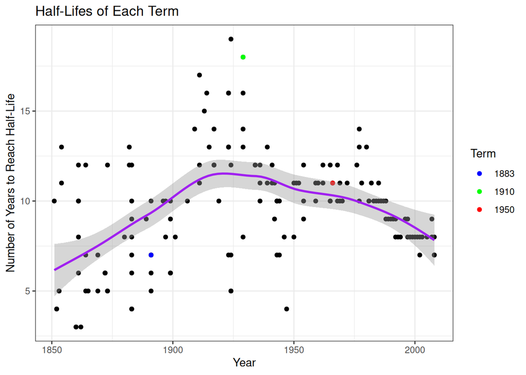

```r
years_and_half_lives %>%
  filter(year >= 1850 & year <= 2012) %>%
  ggplot(aes(x = year, y = num_of_years_to_reach_half_life)) +
  geom_point() +
  geom_point(data = years_and_half_lives %>%
                    filter((term == '1883' | term == '1910' | term == '1950') & (year >= 1850 & year <= 2012)) %>%
                    mutate(term = as.character(term)),
             aes(color = term)) +
  geom_smooth(color = 'purple') +
  scale_color_manual(values = c('1883' = "blue", '1910' = "green", '1950' = "red")) +
  labs(x = 'Year',
       y = 'Number of Years to Reach Half-Life',
       title = 'Half-Lifes of Each Term',
       color = 'Term')
```

## Step 4: Conclusion

# Part G

> Were there any years that were outliers such as years that were forgotten particularly quickly or particularly slowly? Briefly speculate about possible reasons for that pattern and explain how you identified the outliers.

## Step 1: Conclusion

The years 1855, 1856, and 1857 were forgotten the fastest, each reaching their half-life after only 3 years. The year 1900 was forgotten the slowest, taking 19 years to reach its half-life. (I identified these outliers by finding the minimum and maximum values of the number of years required to reach half-life.)

One possible explanation is that 1900 remained memorable for a longer period because it marked the beginning of a new century, causing it to be referenced more frequently over time.

```r
years_and_half_lives %>%
  ungroup() %>%
  filter(year >= 1850 & year <= 2012) %>%
  select(term, num_of_years_to_reach_half_life) %>%
  filter(num_of_years_to_reach_half_life == min(num_of_years_to_reach_half_life) |
         num_of_years_to_reach_half_life == max(num_of_years_to_reach_half_life)) %>%
  rename('outlier_terms' = term, 'min/max_half_life_vals' = num_of_years_to_reach_half_life)
```

```
## # A tibble: 4 × 2
##   outlier_terms `min/max_half_life_vals`
##           <dbl>                    <dbl>
## 1          1855                        3
## 2          1857                        3
## 3          1900                       19
## 4          1856                        3
```

# Makefile

Edit the `Makefile` in this directory to execute the full set of scripts that download the data, clean it, and produce this report. This must be turned in with your assignment such that running `make` on the command line produces the final report as a pdf file.